# BodyFat prediction with multiple linear regression - R

Marco Scatassi, Niccolò Puccinelli

7/11/2021

# ABSTRACT

In the following research we present an analysis of the “Bodyfat” dataset. The purpose of the project is to be able to predict the body fat percentage using easily obtainable physical measures. The dataset is explored and then divided into a training set containing the 80% of the initial observations, chosen randomly, and a test set containing the remaining 20%. Subsequently, a descriptive analysis of the training-set is carried out, paying particular attention to the correlation between the variables collected in it. Several regression models are then developed and compared.

# 1. DATASET DESCRIPTION

- *Density* determined from underwater weighing
- Percent body fat from Siri’s (1956) equation (**target** variable)
- *Age* (years)
- *Weight* (pnd)
- *Height* (inches)
- *Neck* circumference (cm)
- *Chest* circumference (cm)
- *Abdomen* circumference (cm)
- *Hip* circumference (cm)
- *Thigh* circumference (cm)
- *Knee* circumference (cm)
- *Ankle* circumference (cm)
- *Biceps* (extended) circumference (cm)
- *Forearm* circumference (cm)
- *Wrist* circumference (cm)

The body fat percentage is calculated from the *Density* variable using the following equation:

$\%$ $BodyFat$ $=$ $(\frac{495}{Density}) - 450$

There is therefore a direct linear relationship between *BodyFat* and $Density ^ {- 1}$, making the use of *Density* as an explanatory variable in a regression model insignificant. *Density* will in any case be used for a comparison with the regression model consisting of the variables concerning physical measurements.

# 2. LIBRARIES USED

The following libraries were used:

- *fBasics*: *basicStats* function for a summary of the main statistical values.
- *tidyverse*: package containing various graphic and organizational utilities. In particular:
  - *ggplot2*: library for the creation and the manipulation of graphics.
  - *ggthemes*: library used for a purely aesthetic improvement of graphics.
  - *dplyr*: library for data management.
- *gridExtra*: *grid.arrange* function for multiple presentation of graphs created with *ggplot2*.
- *ggpubr*: library containing further graphic and textual utilities.
- *corrplot*: library used for the creation of correlation graphs.
- *MASS*: library containing the *stepAIC* function, which makes a *stepwise* selection of the model.
- *lindia*: *gg_qplot* function for a better visualization of the Normal-QQ Plot.
- *knitr*: library containing utilities for graphical display of tables in R-Markdown.

# 3. DESCRIPTIVE ANALYSIS

## 3.1 Open csv and variable management

For interpretative convenience let’s change the unit of measurement of the variables *Height* (from inch to cm) and *Weight* (from pnd to kg).

The dataset is now presented in the following form.

| Density | BodyFat | Age | Weight | Height | Neck | Chest | Abdomen | Hip | Thigh | Knee | Ankle | Biceps | Forearm | Wrist |
| --- | --- | --- | --- | --- | --- | --- | --- | --- | --- | --- | --- | --- | --- | --- |
| 1.0708 | 12.3 | 23 | 69.96671 | 172.085 | 36.2 | 93.1 | 85.2 | 94.5 | 59.0 | 37.3 | 21.9 | 32.0 | 27.4 | 17.1 |
| 1.0853 | 6.1 | 22 | 78.58497 | 183.515 | 38.5 | 93.6 | 83.0 | 98.7 | 58.7 | 37.3 | 23.4 | 30.5 | 28.9 | 18.2 |
| 1.0414 | 25.3 | 22 | 69.85331 | 168.275 | 34.0 | 95.8 | 87.9 | 99.2 | 59.6 | 38.9 | 24.0 | 28.8 | 25.2 | 16.6 |
| 1.0751 | 10.4 | 26 | 83.80129 | 183.515 | 37.4 | 101.8 | 86.4 | 101.2 | 60.1 | 37.3 | 22.8 | 32.4 | 29.4 | 18.2 |
| 1.0340 | 28.7 | 24 | 83.57449 | 180.975 | 34.4 | 97.3 | 100.0 | 101.9 | 63.2 | 42.2 | 24.0 | 32.2 | 27.7 | 17.7 |
| 1.0502 | 20.9 | 24 | 95.36791 | 189.865 | 39.0 | 104.5 | 94.4 | 107.8 | 66.0 | 42.0 | 25.6 | 35.7 | 30.6 | 18.8 |

## 3.2 Identification and removal of null and inconsistent values

The dataset has no null values.

|  | Density | BodyFat | Age | Weight | Height | Neck | Chest | Abdomen | Hip | Thigh | Knee | Ankle | Biceps | Forearm | Wrist |
| --- | --- | --- | --- | --- | --- | --- | --- | --- | --- | --- | --- | --- | --- | --- | --- |
| Nan | 0 | 0 | 0 | 0 | 0 | 0 | 0 | 0 | 0 | 0 | 0 | 0 | 0 | 0 | 0 |

In order to identify inconsistent values we proceed as follows:

- Let’s display the scatter plot between $Density ^ {- 1}$ and *BodyFat*. In accordance with the previous relation the points should be substantially aligned in such a way as to form a straight line.
- In the dataset there are inconsistent measurements (e.g. subject 75 cm tall with a weight of about 120 kg). Let’s display the box plots of the variables *Height*, *Weight* and *Ankle*, in order to identify and remove them.

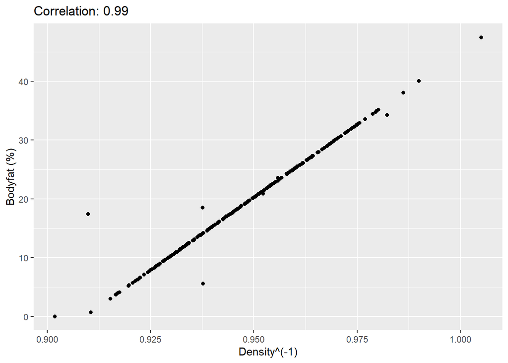

From the graph we can see 4 inconsistent observations, which turn out to be:

- 48
- 76
- 96
- 182

We proceed removing them.

```r
bodyfat <- bodyfat[-c(48, 76, 96, 182), ]
```

So let’s consider the box plots of *Height*, *Weight* and *Ankle*.

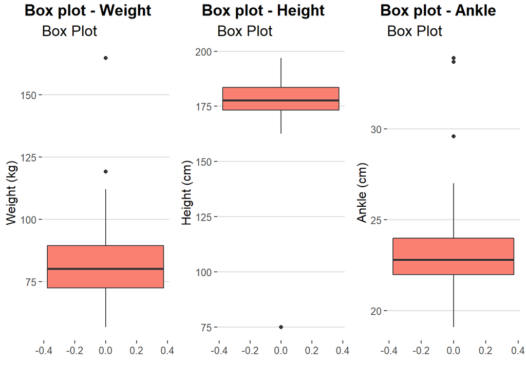

There are four extremely anomalous observations, i.e. those related to:

- Subject with *Height* approximately equal to 75 cm.
- Subject with *Weight* approximately equal to 160 kg.
- Subjects with *Ankle* approximately equal to 35 cm.

So let’s proceed with their removal and check the box plots of the remaining variables.

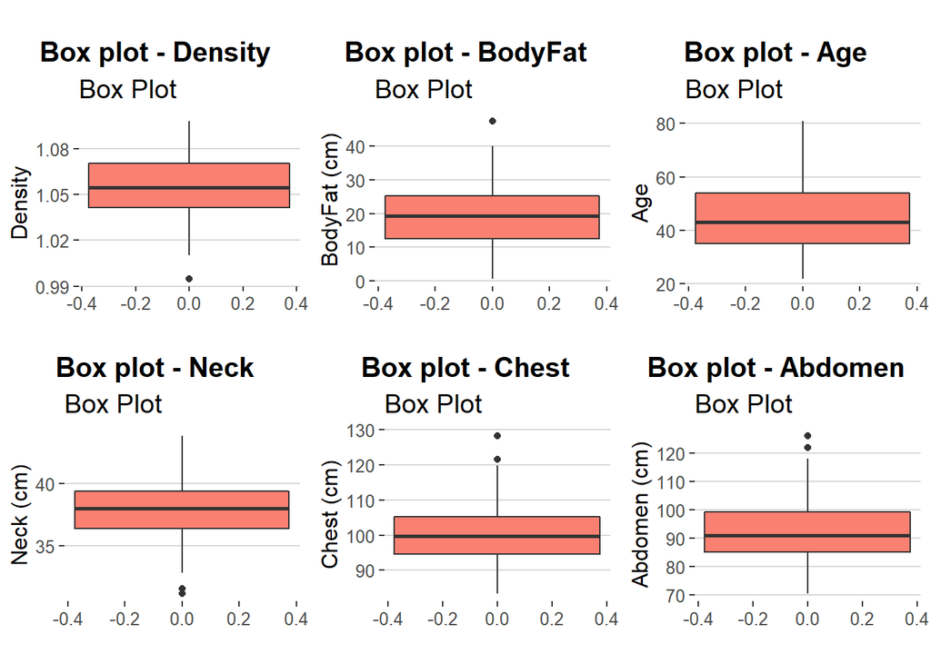

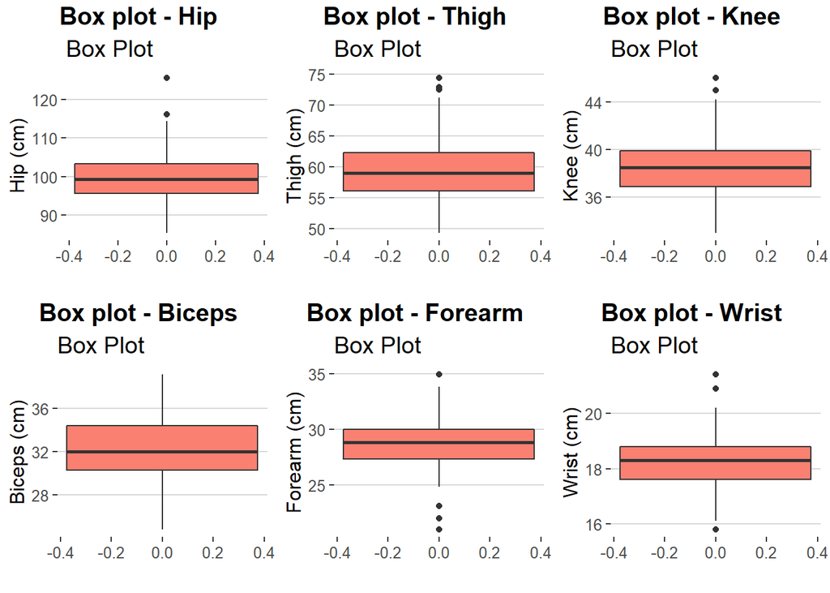

No further inconsistent observations can be found from the previous box plots. The analysis of the anomalous values will be addressed in the regression phase.

## 3.4 One-factor analysis

Before studying in detail the correlations between the variables of the dataset (in particular with the target), we investigate the possible dependence in mean between the age of the subjects and the percentage of body fat.

Let’s see if the target variable *BodyFat* is influenced by belonging to a certain age group.

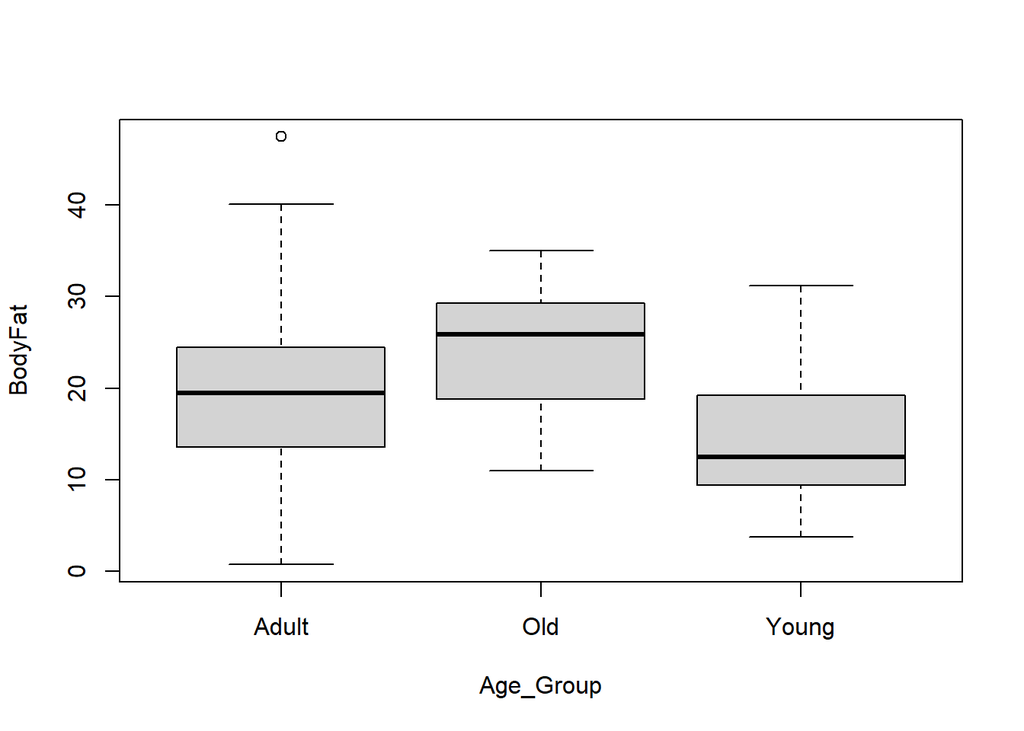

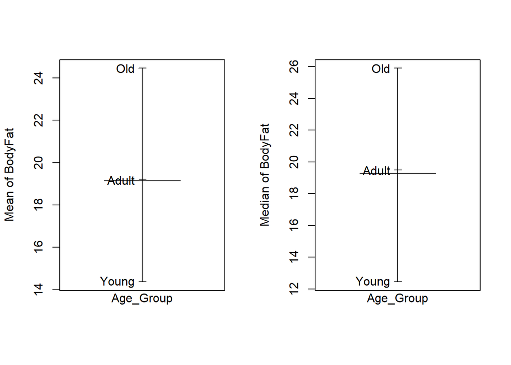

As can be seen from the previous graphs, both the mean and the median of *BodyFat* are the highest in correspondence of the *Old* range, while they are the lowest for the *Young* range. The within-group variability appears to be comparable, as also deduced from the Bartlett test.

```r
bartlett.test(bodyfat_order_age$BodyFat,bodyfat_order_age$Age_Group)
```

```
##
##  Bartlett test of homogeneity of variances
##
## data:  bodyfat_order_age$BodyFat and bodyfat_order_age$Age_Group
## Bartlett's K-squared = 2.6151, df = 2, p-value = 0.2705
```

Before proceeding with the one-factor analysis of variance, let’s verify the normality of the data in the various groups, by using *qqnorm* and the values of skewness and kurtosis.

|  | BodyFat_Young | BodyFat_Adult | BodyFat_Old |
| --- | --- | --- | --- |
| skewness | 0.536999 | 0.278809 | -0.519809 |
| kurtosis | -0.605540 | 0.051823 | -0.757190 |

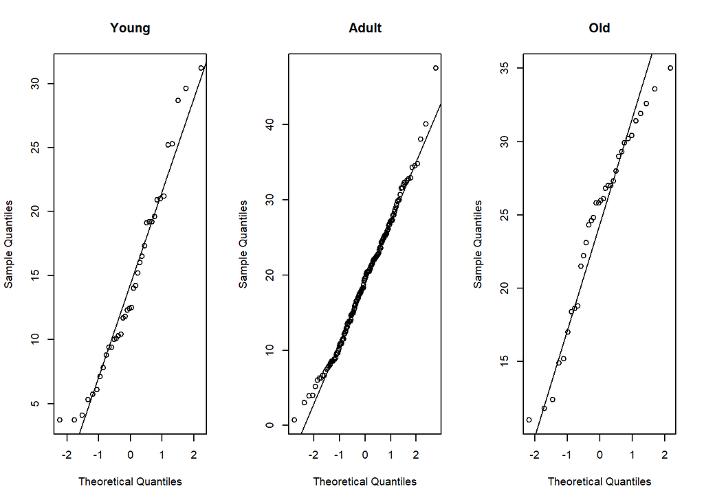

The values in the table of skewness and kurtosis, the qqplots and what has already been shown regarding the variance of the groups show the applicability of the hypotheses of normality and homoskedasticity.

Similar considerations can be made by observing the following graph, which shows the density functions of *BodyFat* with respect to the three groups. The centers of the latter, in the dispersion diagram, show an increasing trend as the age group increases.

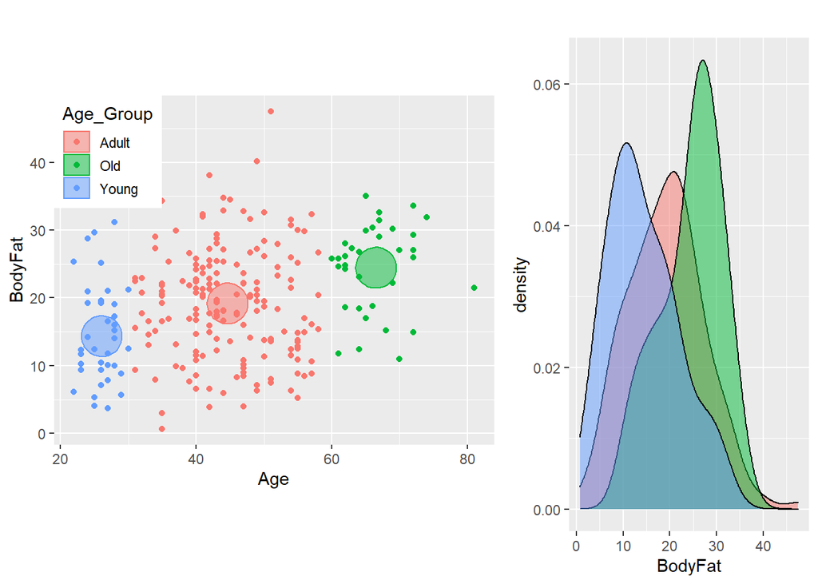

So let’s apply the single factor hypothesis test.

```r
oneway.test(bodyfat_order_age$BodyFat ~ bodyfat_order_age$Age_Group, var.equal = TRUE)
```

```
##
##  One-way analysis of means
##
## data:  bodyfat_order_age$BodyFat and bodyfat_order_age$Age_Group
## F = 15.046, num df = 2, denom df = 241, p-value = 6.959e-07
```

```r
qf(0.95,2,244)
```

```
## [1] 3.032816
```

The previous results lead to the rejection of the null hypothesis: the value of the calculated F-statistic is greater than the threshold of the critical region.

We can therefore conclude by stating that there is dependence in mean between the age group and the percentage of body fat.

## 3.5 Train-test split

Now we divide the dataset into two different parts: a training set (80%) and a test set (20%). The selection is computed randomly using the *sample* function.

```r
set.seed(123)
train = sample(1:nrow(bodyfat), size = 0.8 * nrow(bodyfat))
bodyfat.train = bodyfat[train, -c(16)]
bodyfat.test = bodyfat[-train, -c(16)]
```

## 3.6 Descriptive analysis on the training set

Let’s study the *BodyFat* target variable.

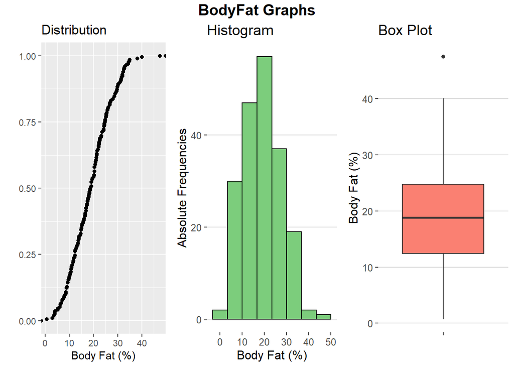

| basicStat | BodyFat |
| --- | --- |
| nobs | 195.000000 |
| NAs | 0.000000 |
| Minimum | 0.700000 |
| Maximum | 47.500000 |
| 1. Quartile | 12.400000 |
| 3. Quartile | 24.750000 |
| Mean | 19.037436 |
| Median | 18.800000 |
| Variance | 72.330499 |
| Stdev | 8.504734 |
| Skewness | 0.271326 |
| Kurtosis | -0.299559 |

As can be seen from the graphs and the summary table of the main statistics, the target variable has a substantially symmetrical distribution. Kurtosis index is also very close to zero. Basically *BodyFat* distribution is comparable to a normal one and this is also justified by the qqplot and the Shapiro-Wilk test.

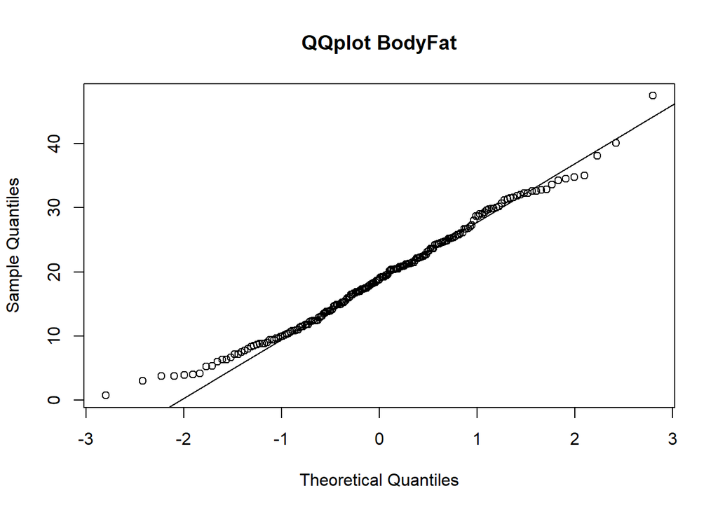

```r
shapiro.test(bodyfat.train$BodyFat)
```

```
##
##  Shapiro-Wilk normality test
##
## data:  bodyfat.train$BodyFat
## W = 0.98815, p-value = 0.104
```

We get a *p-value* of about 0.1 $>$ 0.05, so we accept the null hypothesis.

The dispersion graphs between *BodyFat* and the other covariates of the dataset are now illustrated, in order to have an idea of which variables are correlated the most to the target one.

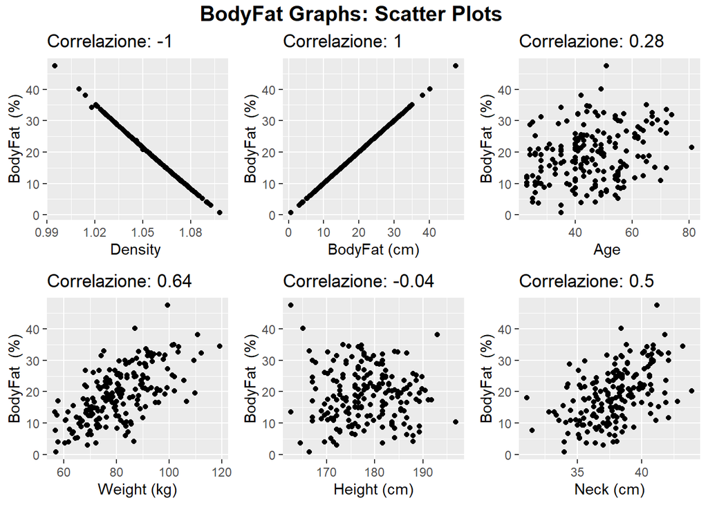

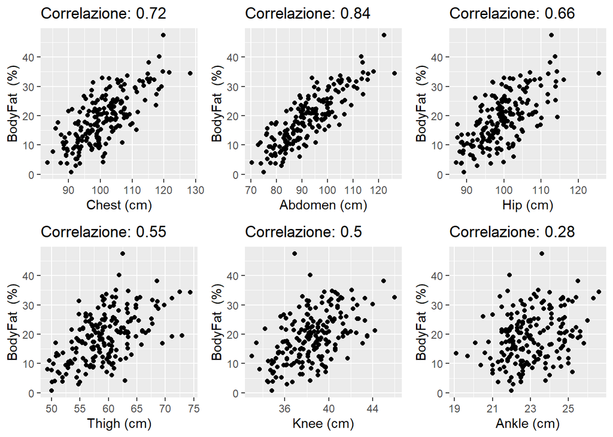

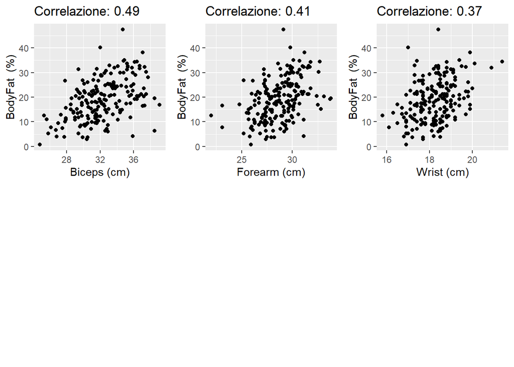

For the same reason we can consider the following graphical representation of the correlation matrix.

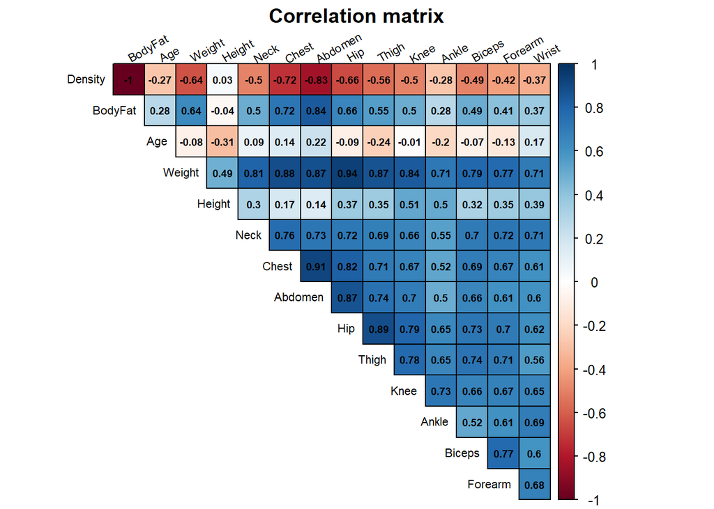

From the two previous graphical representations we can assume that the variables correlated the most to *BodyFat* (not considering *Density*) are, in order:

- Abdomen (0.84)
- Chest (0.72)
- Hip (0.66)
- Weight (0.64)
- Thigh (0.55)
- Knee (0.5)
- Neck (0.5)

Analyzing the correlation matrix associated with the identified variables, it can be observed that these are also very correlated with each other.

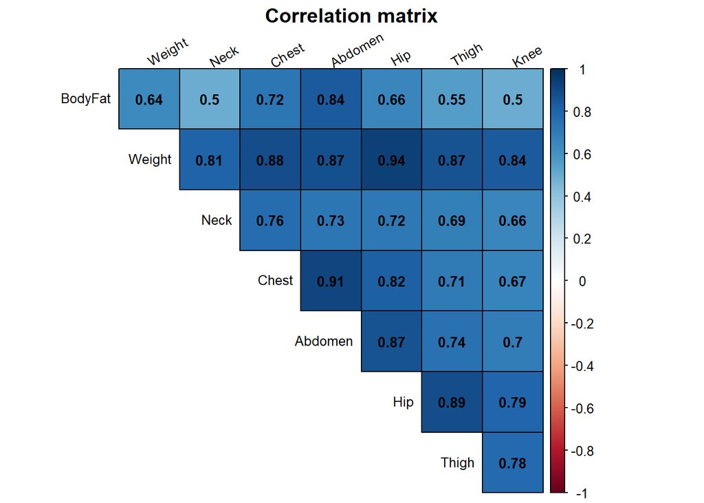

In particular, in order to build a regression model, the correlations between the first 4 variables related the most to *BodyFat* turn out to be problematic.

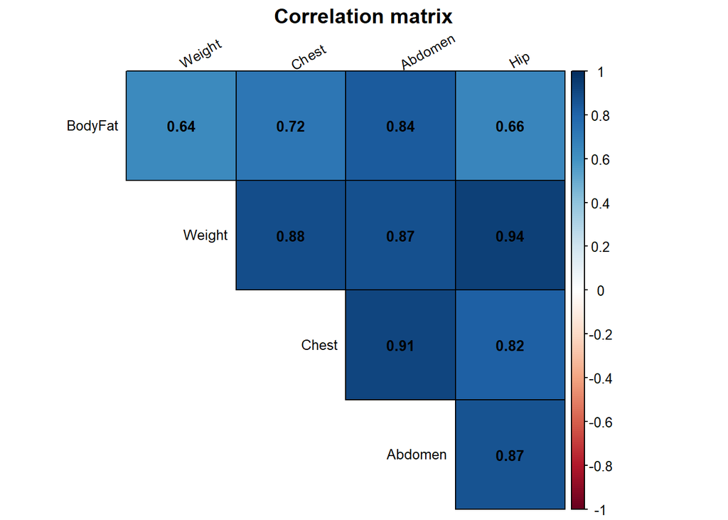

Let us now try to distinguish whether the correlation with the target variable is direct or due to some relationship between the internal variables, i.e. whether or not we have spurious correlations.

The following tables show in the second column the partial correlation between the above variables, with respect to the covariate on the corresponding row.

|  | BodyFat-Abdomen |
| --- | --- |
| Weight | 0.7415155 |
| Chest | 0.6196598 |
| Hip | 0.7086126 |

|  | BodyFat-Weight |
| --- | --- |
| Chest | 0.0019561 |
| Abdomen | -0.3405591 |
| Hip | 0.0885973 |

|  | BodyFat-Chest |
| --- | --- |
| Weight | 0.4431360 |
| Abdomen | -0.1667437 |
| Hip | 0.4284247 |

|  | BodyFat-Hip |
| --- | --- |
| Weight | 0.2205946 |
| Chest | 0.1607500 |
| Abdomen | -0.2499986 |

From the previous tables we can substantially observe that only the correlation of the variable *Abdomen* with *BodyFat* is poorly influenced by the correlation between *Abdomen* and the other variables.

Instead, the correlation between *Weight* and *BodyFat* can be almost totally explained by *Chest*. Similarly, the correlation between *Chest* and *BodyFat* can be almost totally explained by *Abdomen* and the correlation between *Hip* and *BodyFat* depends almost entirely on the correlation between *Hip* and the other variables.

# 4 MULTIPLE LINEAR REGRESSION

## 4.1 Variable selection

We face the problem of multiple linear regression starting from the considerations made previously about the correlations between the dataset variables.

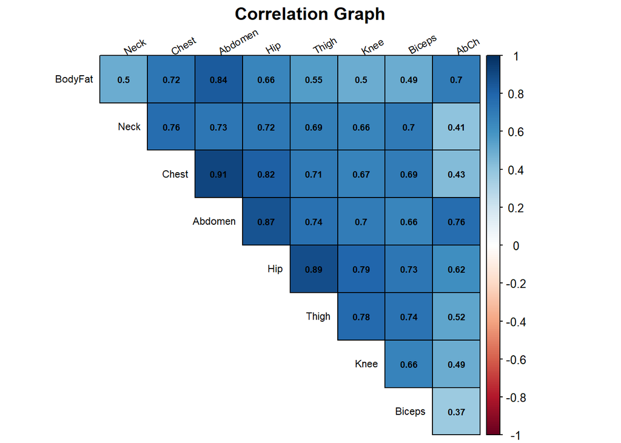

The *AbCh* variable is highly correlated to *BodyFat* and the multicollinearity problem has been reduced. However, we can make a further selection:

- *Abdomen* and *AbCh* are obviously very related. We remove *Abdomen*;
- After *Abdomen*, *Hip* is the covariate most related to *AbCh* (and to the other covariates). We also remove *Hip*.

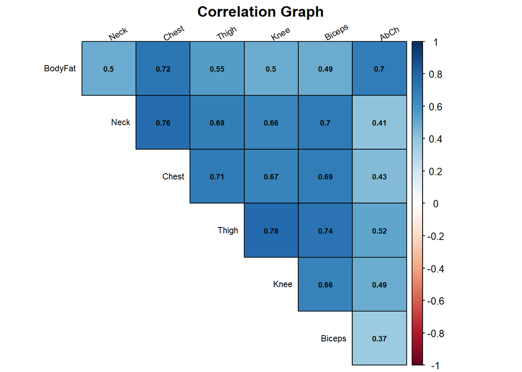

Although it still exists, the problem of multicollinearity has been reduced.

## 4.2 The regression model

For the initial building of the regression model we use the three covariates related the most to *BodyFat* (*AbCh*, *Chest* and *Thigh*), leaving momentarily aside *Neck*, *Knee* and *Biceps*.

Now let’s choose the regression model. We use the `stepAIC` function for a *stepwise* selection of the model, given the target variable *BodyFat* and the covariates *AbCh*, *Chest* and *Thigh*.

```
##
## Call:
## lm(formula = BodyFat ~ Chest + Thigh + AbCh, data = bodyfat.train.1)
##
## Residuals:
##      Min       1Q   Median       3Q      Max
## -10.2771  -3.5001  -0.0223   3.3945  12.2501
##
## Coefficients:
##               Estimate Std. Error t value Pr(>|t|)
## (Intercept) -114.75839    6.53650 -17.557   <2e-16 ***
## Chest          0.63725    0.05805  10.978   <2e-16 ***
## Thigh         -0.24970    0.10012  -2.494   0.0135 *
## AbCh          92.14535    8.18060  11.264   <2e-16 ***
## ---
## Signif. codes:  0 '***' 0.001 '**' 0.01 '*' 0.05 '.' 0.1 ' ' 1
##
## Residual standard error: 4.575 on 191 degrees of freedom
## Multiple R-squared:  0.7151, Adjusted R-squared:  0.7106
## F-statistic: 159.8 on 3 and 191 DF,  p-value: < 2.2e-16
```

The R-squared index indicates that approximately 71% of the total variability is explained by the relationship between *AbCh*, *Chest* and *Thigh*. Covariates and intercept are significant. Let’s continue with the residue analysis.

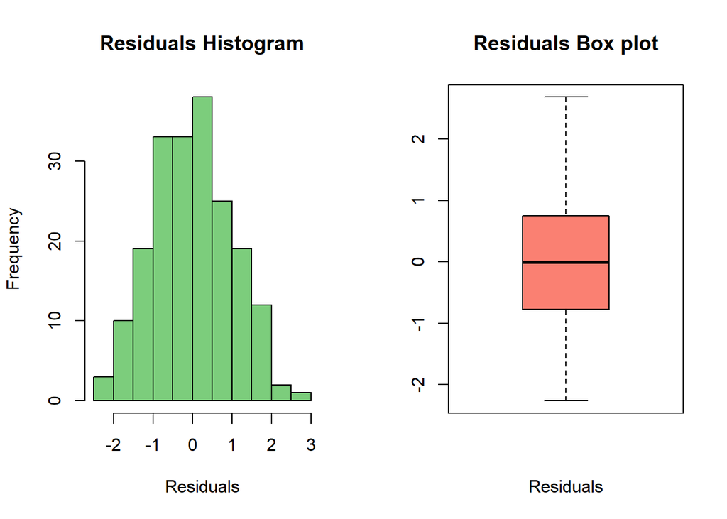

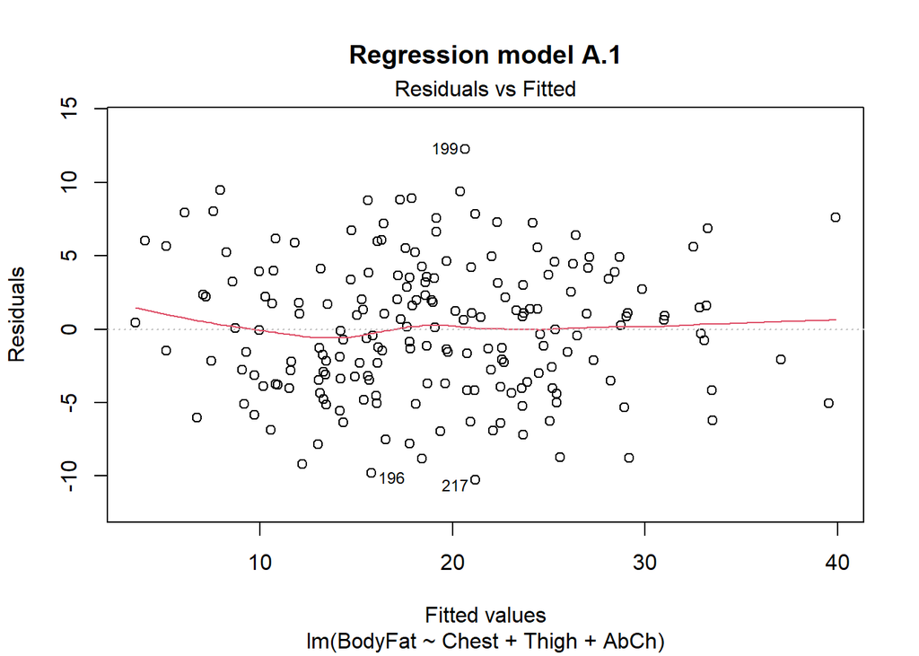

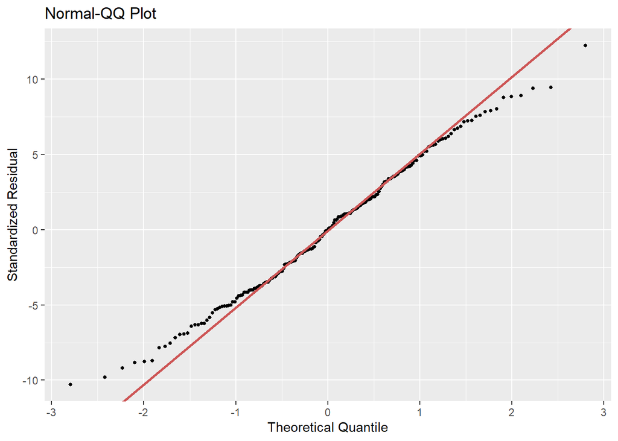

The residual scatter plot has a smooth trend around 0, showing a linear relationship. This therefore does not suggest the introduction of a term, for example, quadratic or cubic.

The quantile-quantile diagram, on the other hand, presents a line that follows the trend of the points representing the standardized residuals, with the exception of the tails, where the points are moderately distant from the line.

So let’s try to improve the model by adding another covariate, chosen from *Neck*, *Knee* and *Biceps*:

```
## Analysis of Variance Table
##
## Model 1: BodyFat ~ Chest + Thigh + AbCh
## Model 2: BodyFat ~ Chest + Thigh + AbCh + Neck
##   Res.Df    RSS Df Sum of Sq      F   Pr(>F)
## 1    191 3998.0
## 2    190 3795.8  1    202.13 10.118 0.001715 **
## ---
## Signif. codes:  0 '***' 0.001 '**' 0.01 '*' 0.05 '.' 0.1 ' ' 1
```

```
## Analysis of Variance Table
##
## Model 1: BodyFat ~ Chest + Thigh + AbCh
## Model 2: BodyFat ~ Chest + Thigh + AbCh + Knee
##   Res.Df    RSS Df Sum of Sq      F  Pr(>F)
## 1    191 3998.0
## 2    190 3906.2  1    91.758 4.4632 0.03594 *
## ---
## Signif. codes:  0 '***' 0.001 '**' 0.01 '*' 0.05 '.' 0.1 ' ' 1
```

```
## Analysis of Variance Table
##
## Model 1: BodyFat ~ Chest + Thigh + AbCh
## Model 2: BodyFat ~ Chest + Thigh + AbCh + Biceps
##   Res.Df    RSS Df Sum of Sq      F Pr(>F)
## 1    191 3998.0
## 2    190 3995.2  1    2.7986 0.1331 0.7156
```

From the analysis of the tables, *Neck* turns out to be the most significant. So let’s add *Neck* and see if it is possible to further improve the model by adding the other significant covariate, that is *Knee*.

```
## Analysis of Variance Table
##
## Model 1: BodyFat ~ Chest + Thigh + AbCh + Neck
## Model 2: BodyFat ~ Chest + Thigh + AbCh + Neck + Knee
##   Res.Df    RSS Df Sum of Sq      F  Pr(>F)
## 1    190 3795.8
## 2    189 3739.8  1    56.049 2.8326 0.09402 .
## ---
## Signif. codes:  0 '***' 0.001 '**' 0.01 '*' 0.05 '.' 0.1 ' ' 1
```

```
##
## Call:
## lm(formula = BodyFat ~ Chest + Thigh + AbCh + Neck + Knee, data = bodyfat.train.1)
##
## Residuals:
##     Min      1Q  Median      3Q     Max
## -9.7937 -3.0974 -0.0233  2.9785 12.7450
##
## Coefficients:
##               Estimate Std. Error t value Pr(>|t|)
## (Intercept) -101.63461    7.33006 -13.865  < 2e-16 ***
## Chest          0.76661    0.06732  11.388  < 2e-16 ***
## Thigh         -0.05670    0.11675  -0.486  0.62778
## AbCh          94.72244    8.03418  11.790  < 2e-16 ***
## Neck          -0.66732    0.23010  -2.900  0.00417 **
## Knee          -0.38068    0.22619  -1.683  0.09402 .
## ---
## Signif. codes:  0 '***' 0.001 '**' 0.01 '*' 0.05 '.' 0.1 ' ' 1
##
## Residual standard error: 4.448 on 189 degrees of freedom
## Multiple R-squared:  0.7335, Adjusted R-squared:  0.7264
## F-statistic:   104 on 5 and 189 DF,  p-value: < 2.2e-16
```

As can be seen from the table, the *Thigh* covariate is no longer significant. Let’s remove it and re-analyze the model.

```
##
## Call:
## lm(formula = BodyFat ~ Chest + AbCh + Neck + Knee, data = bodyfat.train.1)
##
## Residuals:
##     Min      1Q  Median      3Q     Max
## -9.8695 -3.0646 -0.0182  3.0634 12.7538
##
## Coefficients:
##               Estimate Std. Error t value Pr(>|t|)
## (Intercept) -100.65800    7.03462 -14.309  < 2e-16 ***
## Chest          0.75905    0.06536  11.613  < 2e-16 ***
## AbCh          93.91523    7.84454  11.972  < 2e-16 ***
## Neck          -0.68781    0.22575  -3.047  0.00264 **
## Knee          -0.43412    0.19722  -2.201  0.02893 *
## ---
## Signif. codes:  0 '***' 0.001 '**' 0.01 '*' 0.05 '.' 0.1 ' ' 1
##
## Residual standard error: 4.439 on 190 degrees of freedom
## Multiple R-squared:  0.7332, Adjusted R-squared:  0.7275
## F-statistic: 130.5 on 4 and 190 DF,  p-value: < 2.2e-16
```

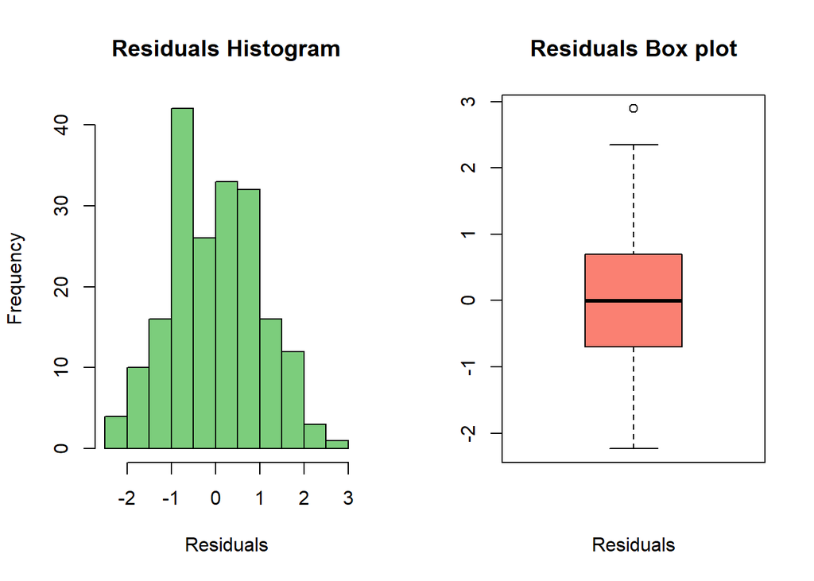

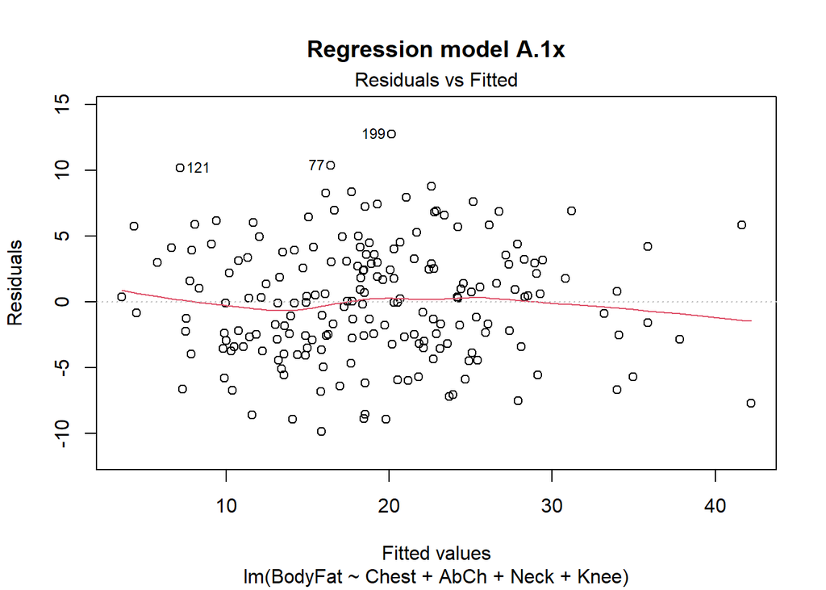

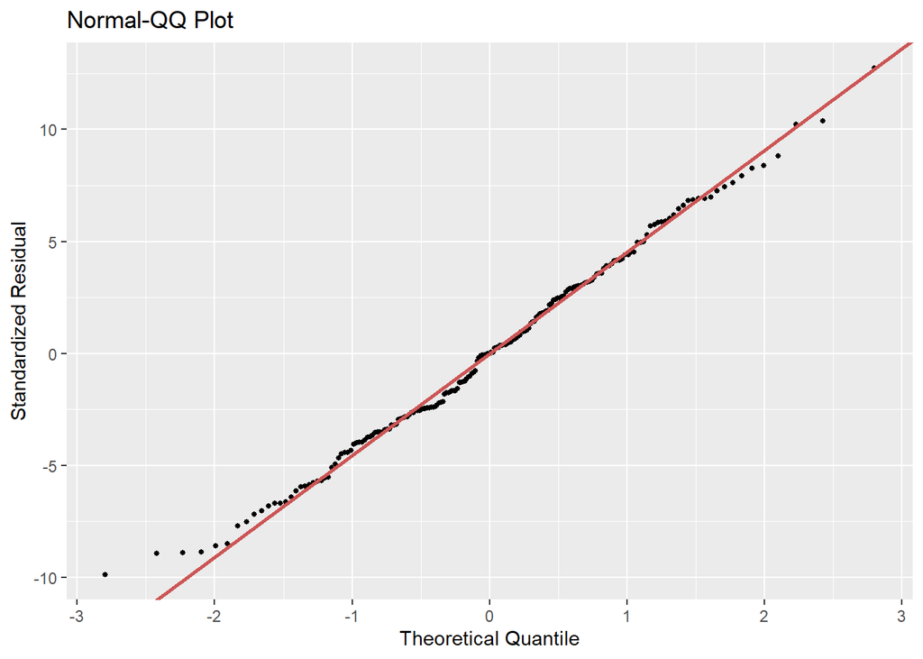

The quantile-quantile diagram is slightly more faithful to the line near the tails. However, analyzing the residual plot, we notice the presence of several outliers. Let’s remove them and fit the model again.

```
##
## Call:
## lm(formula = BodyFat ~ Neck + Chest + Knee + AbCh, data = bodyfat.train.1)
##
## Residuals:
##     Min      1Q  Median      3Q     Max
## -9.5790 -3.0263  0.2223  2.9434  8.9194
##
## Coefficients:
##               Estimate Std. Error t value Pr(>|t|)
## (Intercept) -104.65424    6.79995 -15.390  < 2e-16 ***
## Neck          -0.76573    0.21499  -3.562 0.000469 ***
## Chest          0.80582    0.06362  12.666  < 2e-16 ***
## Knee          -0.46339    0.19107  -2.425 0.016261 *
## AbCh          97.40631    7.55450  12.894  < 2e-16 ***
## ---
## Signif. codes:  0 '***' 0.001 '**' 0.01 '*' 0.05 '.' 0.1 ' ' 1
##
## Residual standard error: 4.194 on 185 degrees of freedom
## Multiple R-squared:  0.7582, Adjusted R-squared:  0.7529
## F-statistic:   145 on 4 and 185 DF,  p-value: < 2.2e-16
```

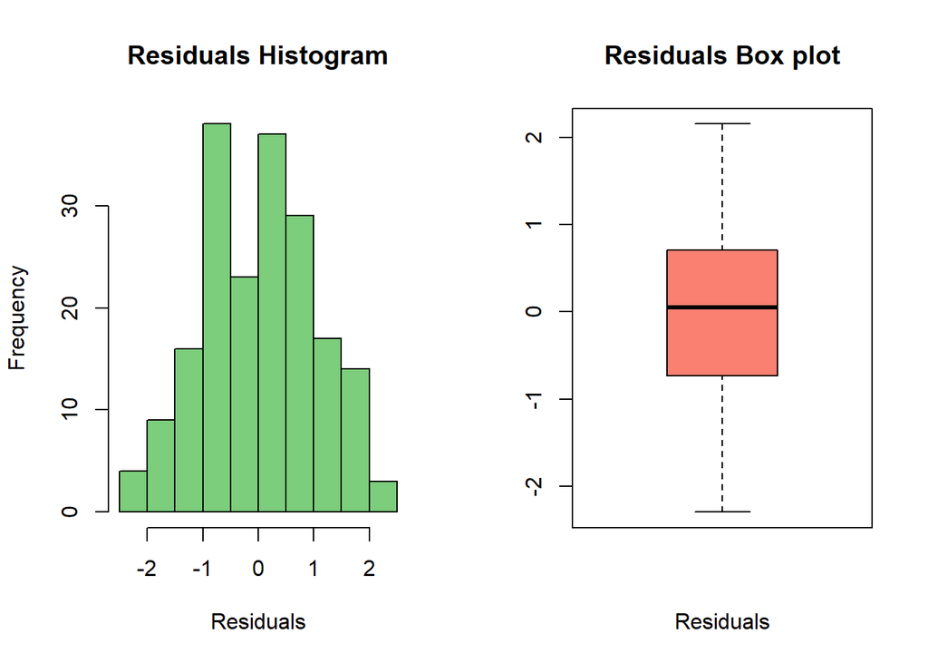

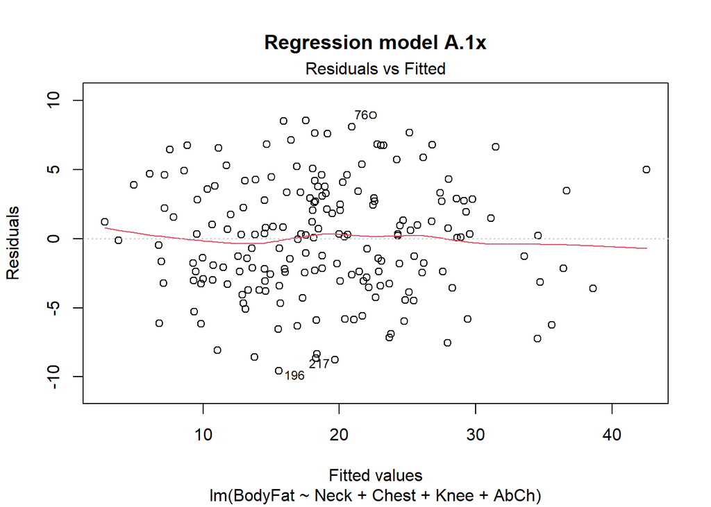

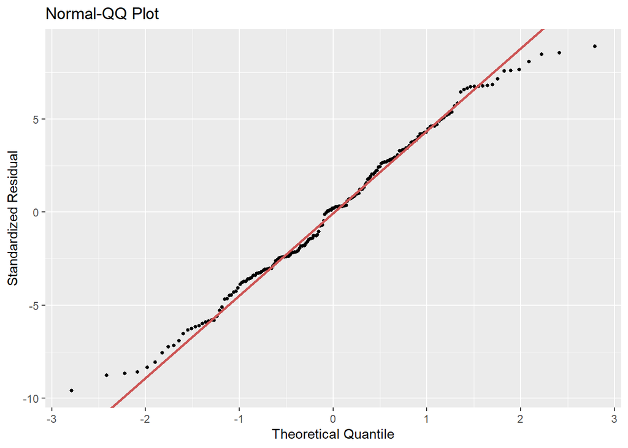

The residual plot has improved significantly and the tails of the quantile-quantile plot diverge in less central positions. Even the R-square index, compared to the original model, is improved, albeit by “only” 4% (from 71% to about 75%).

# 5 PREDICTION AND COMPARISON WITH DENSITY

We evaluate, through the test set, the predictive capabilities of this model, comparing them with the model built using *Density* as single covariate.

## 5.1 Prediction

We check the percentage of “correctly” predicted values with five different percentages of margin (tolerance). Then, we plot the difference, in absolute value, between predicted values and real values.

```
## [1] "Values correctly predicted with 25 % margin:"
## [1] "42/50"
## [1] "Percentage: 84"
```

```
## [1] "Values correctly predicted with 20 % margin:"
## [1] "40/50"
## [1] "Percentage: 80"
```

```
## [1] "Values correctly predicted with 15 % margin:"
## [1] "40/50"
## [1] "Percentage: 80"
```

```
## [1] "Values correctly predicted with 10 % margin:"
## [1] "38/50"
## [1] "Percentage: 76"
```

```
## [1] "Values correctly predicted with 5 % margin:"
## [1] "36/50"
## [1] "Percentage: 72"
```

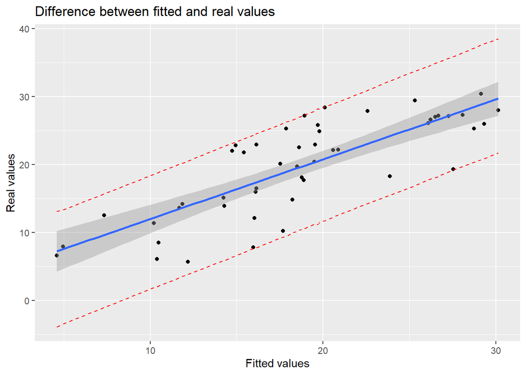

The dashed red lines represent the endpoint of the prediction range, i.e. the uncertainty around the single predicted values. The band around the regression line (in blue) represents the uncertainty around the average forecasts. In both cases, the confidence/tolerance level is 95%.

The data points of the graph are all included between the two dashed red lines. Furthermore, the percentages of correctly predicted values, in relation to the results obtained during the training phase, are excellent. In particular, the model is able to predict 84% of the values with a tolerance of 25% and 72% with a tolerance of 5%, using measurements that are much more convenient to obtain than the density measured underwater.

## 5.2 COMPARISON WITH DENSITY

We make a selection in the regression phase even for the model with *Density* as only covariate, in order to guarantee parity with the previously constructed model.

```
##
## Call:
## lm(formula = BodyFat ~ Density, data = bodyfat.train.density)
##
## Residuals:
##      Min       1Q   Median       3Q      Max
## -1.51862 -0.11566 -0.05211  0.10199  1.43879
##
## Coefficients:
##              Estimate Std. Error t value Pr(>|t|)
## (Intercept)  489.1647     0.9095   537.9   <2e-16 ***
## Density     -445.3302     0.8613  -517.0   <2e-16 ***
## ---
## Signif. codes:  0 '***' 0.001 '**' 0.01 '*' 0.05 '.' 0.1 ' ' 1
##
## Residual standard error: 0.229 on 193 degrees of freedom
## Multiple R-squared:  0.9993, Adjusted R-squared:  0.9993
## F-statistic: 2.673e+05 on 1 and 193 DF,  p-value: < 2.2e-16
```

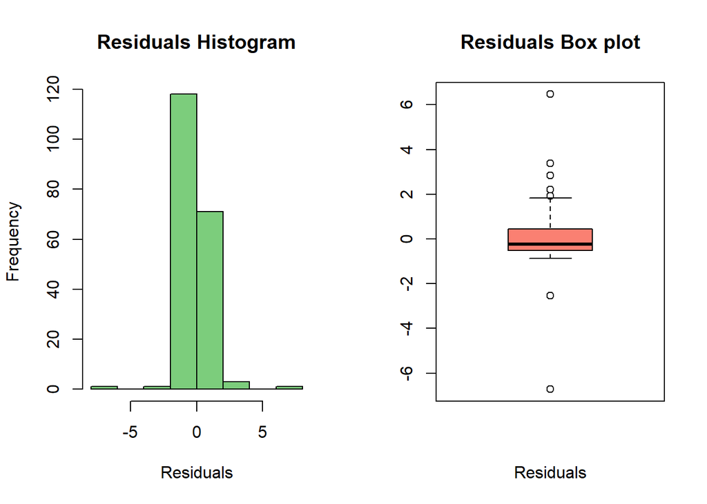

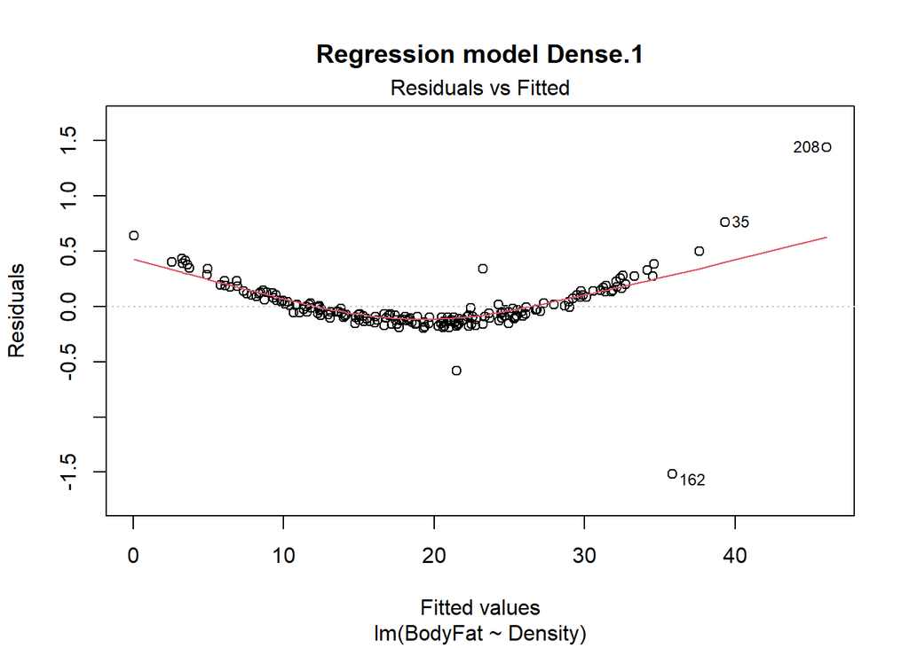

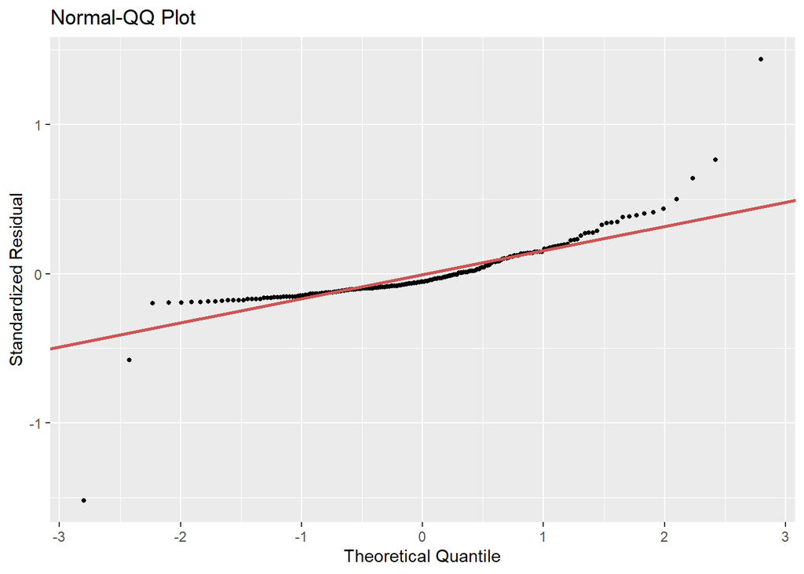

The R-squared index is very high, as we expected. However, analyzing the residual dispersion diagram, we notice a slightly parabolic trend. So let’s try to add a quadratic term.

```
##
## Call:
## lm(formula = BodyFat ~ Density + I(Density^2), data = bodyfat.train.density)
##
## Residuals:
##      Min       1Q   Median       3Q      Max
## -1.86579 -0.02473  0.00524  0.03719  0.45605
##
## Coefficients:
##              Estimate Std. Error t value Pr(>|t|)
## (Intercept)    908.98      26.00   34.96   <2e-16 ***
## Density      -1242.32      49.35  -25.18   <2e-16 ***
## I(Density^2)   378.14      23.41   16.15   <2e-16 ***
## ---
## Signif. codes:  0 '***' 0.001 '**' 0.01 '*' 0.05 '.' 0.1 ' ' 1
##
## Residual standard error: 0.1495 on 192 degrees of freedom
## Multiple R-squared:  0.9997, Adjusted R-squared:  0.9997
## F-statistic: 3.138e+05 on 2 and 192 DF,  p-value: < 2.2e-16
```